# College

444 Lecture 23

Brian Weatherson

2024-04-09

## Assignment

This week’s assignment is about a signaling game.

- First Nature reveals a type (A or B);
- Then Proposer sends a signal (Left or Right);
- Then Responder, seeing the signal but not the state, chooses and action (Up or Down).

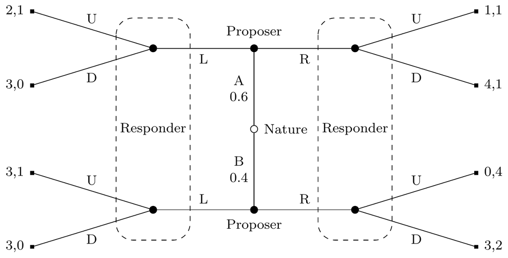

Figure 1: Tree for Weekly 5 practice version

| Type | Proposer | Responder | Payouts |
| --- | --- | --- | --- |
| A | L | D | 3, 0 |
| A | L | U | 2, 1 |
| A | R | D | 4, 1 |
| A | R | U | 1, 1 |
| B | L | D | 3, 0 |
| B | L | U | 3, 1 |
| B | R | D | 3, 2 |
| B | R | U | 0, 4 |

Table 1: Payouts for Weekly 5 practice version

## Strategies

In this tree, Proposer has four possible strategies:

1. Left if A, Left if B (LL)
2. Left if A, Right if B (LR)
3. Right if A, Left if B (RL)
4. Right if A, Right if B (RR)

## Strategies

And Responder has four possible strategies

1. Up if Left, Up if Right (UU)
2. Up if Left, Down if Right (UD)
3. Down if Left, Up if Right (DU)
4. Down if Left, Down if Right (DD)

## Strategy Pairs

So the strategy table has four rows for Proposer, and four columns for Responder, and that means 16 cells.

If there was no randomness, then for any pair, you could tell what each player would get.

But there is randomness. So what do we do?

## Answers

I’ll start with the answers, then work back to how to figure them out.

| P1 | DD | DU | UD | UU |
| --- | --- | --- | --- | --- |
| LL | 3, 0 | 3, 0 | 2.4, 1 | 2.4, 1 |
| LR | 3, 0.8 | 1.8, 1.6 | 2.4, 1.4 | 1.2, 2.2 |
| RL | 3.6, 0.6 | 1.8, 0.6 | 3.6, 1 | 1.8, 1 |
| RR | 3.6, 1.4 | 0.6, 2.2 | 3.6, 1.4 | 0.6, 2.2 |

## Bottom Right

Let’s start in the bottom right, the 0.6, 2.2.

The formula for P1’s expected return is:

- Probability of A times P1’s return if A happens (and they play these strategies); plus
- Probability of B times P1’s return if B happens (and they play these strategies)

## Bottom Right

If A happens, and P1 plays RR, that means P1 chooses R (the first letter in P1’s strategy).

If P1 chooses R, and P2 plays UU, that means P2 chooses U (the second letter in P1’s strategy).

So the row of the table we’re on is where A, then R, then U happen.

| Type | Proposer | Responder | Payouts |
| --- | --- | --- | --- |
| A | L | D | 3, 0 |
| A | L | U | 2, 1 |
| A | R | D | 4, 1 |
| A | R | U | 1, 1 |
| B | L | D | 3, 0 |
| B | L | U | 3, 1 |
| B | R | D | 3, 2 |
| B | R | U | 0, 4 |

And at that row A gets 1.